# Chapter 4

## 4.2 Normality tests

The main tests for the assessment of normality are Kolmogorov-Smirnov (K-S) test, Lilliefors corrected K-S test and Shapiro-Wilk (S-W) test, but there are many more.

The K-S test compares the empirical cumulative distribution function (ECDF) of your sample with the CDF of a *fully specified (theoretical)* distribution, meaning that it cannot be used when you don’t know the population mean or standard deviation. The Lilliefors test is a K-S test that allows you to estimate these parameters from your sample.

A limitation of the K-S test is its high sensitivity to extreme values; the Lilliefors correction renders this test less conservative. Both tend to emphasize differences in the centre rather than tails.

The Shapiro-Wilk test is based on the correlation between the data and the corresponding normal scores and provides better power than the K-S test even after the Lilliefors correction. But the S-W test is very sensitive, especially to deviations in both skewness and kurtosis. It performs better for small to medium samples.

1. Null hypothesis

All those tests share the same null hypothesis: the data sample is (standard) normally distributed. A low p-value suggests that the sample does not come from a normal distribution.

2. Type of data

Continuous numeric data.

3. Requirements

The sample size plays a big role in the choice of the test and its interpretation, but there is no particular requirement on the data.

### 4.2.1 Kolmogorov–Smirnov test

The Kolmogorov–Smirnov test evaluates whether a sample comes from a specific, fully specified continuous distribution, like the standard normal distribution. It cannot be used when you don’t know the population mean or standard deviation.

4. R function

```
ks.test(x, y, ...,
        alternative = c("two.sided", "less", "greater"),
        exact = NULL, simulate.p.value = FALSE, B = 2000)
```

5. Important arguments

- `x`: a numeric vector of data values.
- `y`: either a numeric vector of data values, or a character string naming a cumulative distribution function or an actual cumulative distribution function such as `pnorm` (for comparison with the normal distribution; note that if `mean` or `sd` are not specified, we compare the sample with a *standard* normal distribution).

6. Example

```r
# We perform the Kolmogorov-Smirnov test on weight and height, comparing them
# to a standard normal distribution ("pnorm"), since we don't know their
# true mean and sd.
ks.test(merged_nhanes$BMXWT, "pnorm")
```

```
##
##  Asymptotic one-sample Kolmogorov-Smirnov test
##
## data:  merged_nhanes$BMXWT
## D = 1, p-value < 2.2e-16
## alternative hypothesis: two-sided
```

```r
ks.test(merged_nhanes$BMXHT, "pnorm")
```

```
##
##  Asymptotic one-sample Kolmogorov-Smirnov test
##
## data:  merged_nhanes$BMXHT
## D = 1, p-value < 2.2e-16
## alternative hypothesis: two-sided
```

```r
# As expected, those samples are not *standard* normal distributed.
# If we want to compare the sample to a normal distribution with mean and sd
# estimated from the sample, we need to use a Lilliefors test.
```

#### 4.2.1.1 Lilliefors test

The Lilliefors test adapts the K–S test for normality when mean and SD are estimated from the sample. It corrects for the bias introduced when estimating parameters from the sample.

4. R function

```
lillie.test(x)
```

5. Important arguments

- `x`: a numeric vector of data values, the number of which must be greater than 4. Missing values are allowed.

6. Example

```r
library(nortest)

# We perform the Lilliefors (Kolmogorov-Smirnov) test on weight and height,
# comparing them to a normal distribution.
lillie.test(merged_nhanes$BMXWT)
```

```
##
##  Lilliefors (Kolmogorov-Smirnov) normality test
##
## data:  merged_nhanes$BMXWT
## D = 0.059457, p-value < 2.2e-16
```

```r
lillie.test(merged_nhanes$BMXHT)
```

```
##
##  Lilliefors (Kolmogorov-Smirnov) normality test
##
## data:  merged_nhanes$BMXHT
## D = 0.023034, p-value = 2.905e-08
```

This brings us to the topic of the usefulness of normality tests. Even though our height variable had a perfect Q-Q plot, the Lilliefors test is extremely sensitive here and, because of the large sample size, produces an extremely significant p-value.

### 4.2.2 Shapiro-Wilk test

A test that assesses whether a sample of data comes from a normally distributed population. Like the Lilliefors test, it does not require knowledge of the true population mean and standard deviation, as these are estimated from the sample.

4. R function

```
shapiro.test(x)
```

Performs the Shapiro-Wilk test of normality.

5. Important arguments

- `x`: a numeric vector of data values. Missing values are allowed, but the number of non-missing values must be **between 3 and 5000**.

⚠️ The Shapiro–Wilk test in R requires 3 to 5000 non-missing values because at least 3 points are needed to compute the statistic, and the implementation’s coefficients and numerical accuracy are only valid up to 5000 observations.

6. Example

```r
# Since we have more than 5000 data points, we cannot formally use the S-W
# test on our weight or height; but in order to see how the output would look
# like (/!\ no statistical interpretation possible after that!), let us randomly
# select 5000 values from those variables.
BMXWT_5000 <-  sample(x = merged_nhanes$BMXWT, size = 5000, replace = FALSE)
BMXHT_5000 <-  sample(x = merged_nhanes$BMXHT, size = 5000, replace = FALSE)

# We perform the (statistically invalid) Shapiro-Wilk test on the randomly
# generated n=5000 weight and height.
shapiro.test(BMXWT_5000)
```

```
##
##  Shapiro-Wilk normality test
##
## data:  BMXWT_5000
## W = 0.9542, p-value < 2.2e-16
```

```r
shapiro.test(BMXHT_5000)
```

```
##
##  Shapiro-Wilk normality test
##
## data:  BMXHT_5000
## W = 0.99725, p-value = 8.151e-08
```

# 5 Tests for survival analysis

Before we delve deeper into the log-rank test, let’s briefly discuss censoring, which is a crucial topic in time-to-event analysis.

### 5.0.1 Time-to-event data, censoring

Survival analysis involves measuring the elapsed amount of time that passes between some defined “start time” and some other defined “end point” for each observation (subject, individual, etc.) in the sample population. Quite often, there are observations in a survival analysis for which this elapsed amount of time is unknown. These observations are said to be censored, and the reasons this could occur are explained along with an example below to make it easier to understand.

Consider a hypothetical clinical trial that is scheduled to last for 12 months, and that will include 6 patients. Each patient was followed until one of three things happened:

1. The patient experienced the event of interest
2. The patient dropped out of the study
3. The study ended after 12 months, but the patient did not experience the event in that time

The graph below shows a timeline for each of the 6 patients in the study, along with an indication of whether or not they died (event) or were censored.

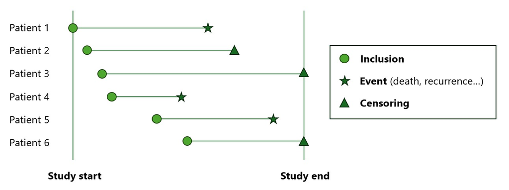

The time-to-event dataset would look like this:

```r
(survival_data <- data.frame(
  id = 1:6,
  time = c(7, 7, 8, 3, 6, 6),
  event = c(1, 1, 0, 1, 1, 0) # (1 = event, 0 = censored)
))
```

| id | time | event |
| --- | --- | --- |
| 1 | 7 | 1 |
| 2 | 7 | 1 |
| 3 | 8 | 0 |
| 4 | 3 | 1 |
| 5 | 6 | 1 |
| 6 | 6 | 0 |

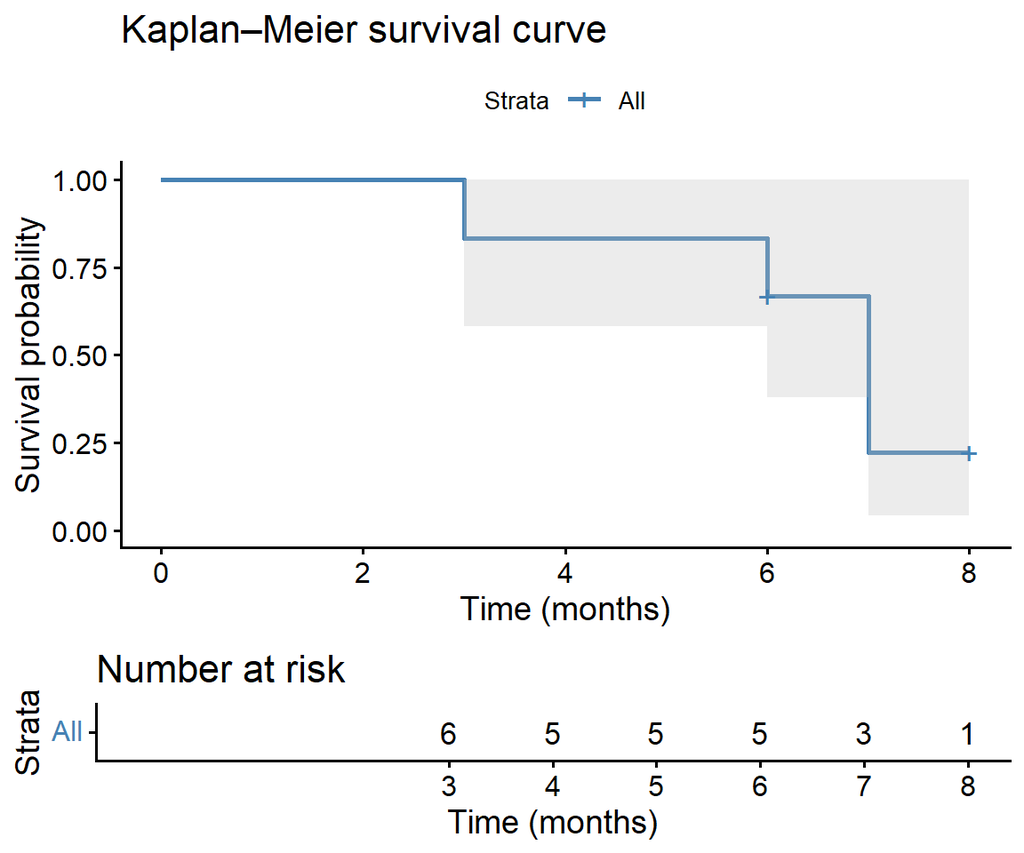

```r
library(survival) # for survfit
library(survminer) # for ggsurvplot

# Let us draw the KM curve and look at the number at risk.
fit <- survfit(Surv(time, event) ~ 1, data = survival_data)
ggsurvplot(fit,
           data = survival_data,
           palette = c("steelblue"),
           conf.int = TRUE,
           xlab = "Time (months)",
           ylab = "Survival probability",
           risk.table = TRUE,
           title = "Kaplan–Meier survival curve")
```

Censored patients are marked on the KM curves with small vertical ticks and do not affect the survival probability; only events do.

The number at risk is shown for each month, from 3 months (when the first patient experienced an event) to 8 months (the longest observation period in the cohort). At each time point, the number at risk is the number of patients who have not yet experienced the event.

## 5.1 Log-Rank test

The log-rank test is a test for analysing time-to-event data. It compares the estimated hazard functions of two groups at each observed event time.

💡 The hazard function $h(t)$, at time $t$, is the instantaneous risk of experiencing the event among those who are still at risk. It is sometimes referred to as the hazard rate. We will discuss the hazard function in more detail when we look at Cox regression.

There are other ways to analyse time-to-event data (e.g. overall survival, recurrence-free survival, time to recurrence, etc.). Among the options, we have already mentioned are Kaplan-Meier curves (see Chapter 3), and we will look at Cox regression at the end of this chapter.

1. Null hypothesis

The null hypothesis is that the two groups have identical hazard functions.

2. Type of data

Time-to-event data for two groups, e.g. overall survival (OS) for “Treatment 1” and “Treatment 2”.

3. Requirements

- The event times of individuals in each group should be **independent** to each other. This assumption implies that the occurrence of an event (e.g., death or failure) for one individual should not influence the occurrence of an event for another individual.
- **Censoring** should **not be related** to the event being studied or to the group assignment (censored and non-censored patients do not differ in terms of their actual event times). The log-rank test assumes that the probability of censoring should be the same for all individuals within each group.
- The hazard rates (the risk of an event occurring) for the compared groups should be consistent over time (we call that **proportional hazards** assumption). The ratio of the hazard rates should remain constant, indicating that the groups are not experiencing significantly different risks at different time points.

4. R function

We need the package `survival` to perform a log-rank test.

```
survdiff(formula, data, subset, na.action, rho=0, timefix=TRUE)
```

5. Important arguments

- `formula`: a formula expression as for other survival models, of the form `Surv(time, status) ~ predictors`.
- `data`: the data frame in which to interpret the variables occurring in the formula.
- `subset`: expression indicating which subset of the rows of data should be used in the fit.

6. Example

```r
# We want to have a look at the survival of people depending on the variable
# SMQ020 (smoked at least 100 cigarettes in life).
# We keep only the responses 'yes' or 'no'.
df <- merged_nhanes_with_mort[merged_nhanes_with_mort$SMQ020 %in% c("Yes", "No"), ]

# We perform the log-rank test.
survdiff(Surv(PERMTH_INT, MORTSTAT) ~ SMQ020, data = df)
```

```
## Call:
## survdiff(formula = Surv(PERMTH_INT, MORTSTAT) ~ SMQ020, data = df)
##
## n=5303, 11 observations deleted due to missingness.
##
##               N Observed Expected (O-E)^2/E (O-E)^2/V
## SMQ020=No  3030      248      336      23.2      56.5
## SMQ020=Yes 2273      330      242      32.4      56.5
##
##  Chisq= 56.5  on 1 degrees of freedom, p= 6e-14
```

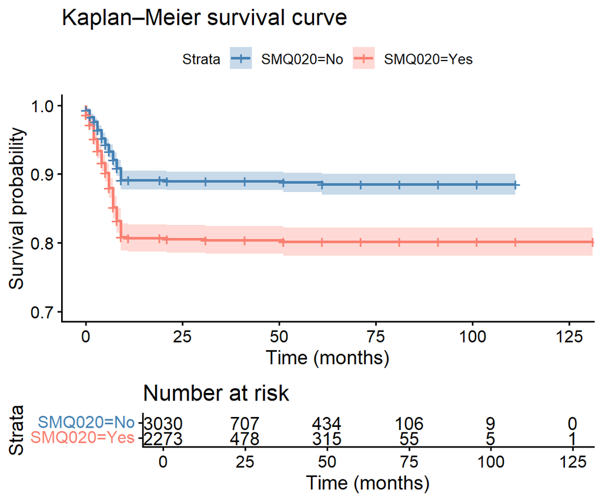

```r
# Smoking has (unsurprisingly) an influence on death. To see in which direction
# (let us assume that we don't know), since the log-rank test does not tell
# us that, we draw the KM curve.
fit <- survfit(Surv(PERMTH_INT, MORTSTAT) ~ SMQ020, data = df)
ggsurvplot(fit,
           data = df,
           palette = c("steelblue", "salmon"),
           conf.int = TRUE,
           xlab = "Time (months)",
           ylab = "Survival probability",
           ylim = c(0.7, 1),
           risk.table = TRUE,
           title = "Kaplan–Meier survival curve")
```

# 6 Correlation and association tests

Correlation coefficients are numerical measure of some type of **correlation**, meaning a statistical relationship (causal or not!) between two variables.

The null hypothesis of “no correlation” as measured by a correlation coefficient can be tested with a statistical hypothesis test.

## 6.1 Correlation test by Pearson

The Pearson correlation coefficient $r$ is a correlation coefficient that measures **linear** correlation between two sets of data. It is the ratio between the covariance of two variables and the product of their standard deviations; thus, it is essentially a normalized measurement of the covariance, such that the result always has a value between $−1$ and $1$:

- $-1$ indicates a perfectly negative linear correlation between two variables
- $0$ indicates no linear correlation between two variables
- $1$ indicates a perfectly positive linear correlation between two variables

⚠️ A Pearson’s correlation coefficient of $0$ does **not** mean that there is no correlation between the two variables! Only that if there is one, it is not linear. Similarly, a non-significant p-value in the Pearson’s correlation test ($p >> 0$) does not prove independence, only that there is no linear association between the variables.

💡 Covariance is a measure of the joint variability of two variables.

1. Null hypothesis

- The correlation coefficient $r$ is equal to $0$ (i.e. no linear correlation)

2. Type of data

- Two vectors of continuous variables (e.g. weight in [kg] and height in [m])

3. Requirements

- The Pearson’s correlation *test* assumes that both variables are roughly *normally distributed*.
- Values in both data vectors must be *paired*, meaning that each element in one vector corresponds to a specific element in the other.

4. R function

`cor.test(x, ...)`: Test for association between paired samples, using one of Pearson’s, Kendall’s or Spearman’s correlation coefficient.

5. Important arguments

```
cor.test(x, y,
         alternative = c("two.sided", "less", "greater"),
         method = c("pearson", "kendall", "spearman"),
         exact = NULL, conf.level = 0.95, continuity = FALSE, ...)
```

- `x, y`: numeric vectors of data values. `x` and `y` must have the same length.
- `alternative`: indicates the alternative hypothesis and must be one of “two.sided”, “greater” or “less”. You can specify just the initial letter. “greater” corresponds to positive association, “less” to negative association.
- `method`: a character string indicating which correlation coefficient is to be used for the test. One of “pearson”, “kendall”, or “spearman”, can be abbreviated.

6. Example

Let us measure the Pearson’s correlation of different pairs of variables:

- `BMXWT`: Weight (kg)
- `BMXHT`: Standing height (cm)
- `BMXBMI`: Body Mass Index (kg/m²)
- `BMXWAIST`: Waist circumference (cm)

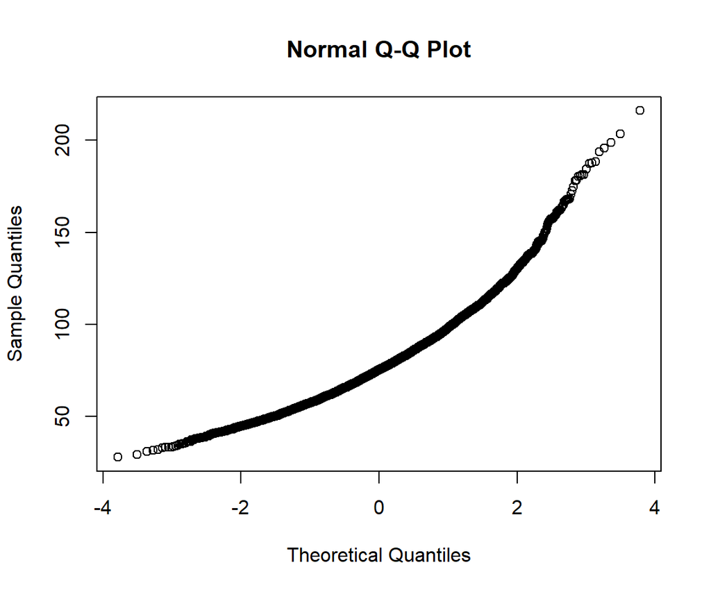

```r
# We quickly check the distribution of weight, BMI, height and waist circumference using Q-Q-plots
qqnorm(y = merged_nhanes$BMXWT)
```

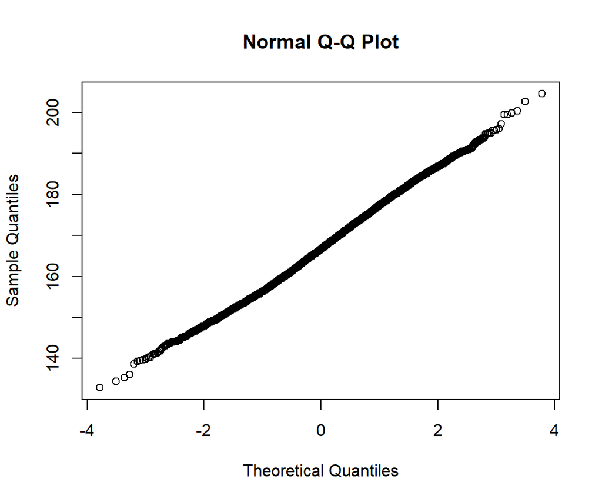

```r
qqnorm(y = merged_nhanes$BMXHT)
```

```r
qqnorm(y = merged_nhanes$BMXBMI)
```

[output not shown]

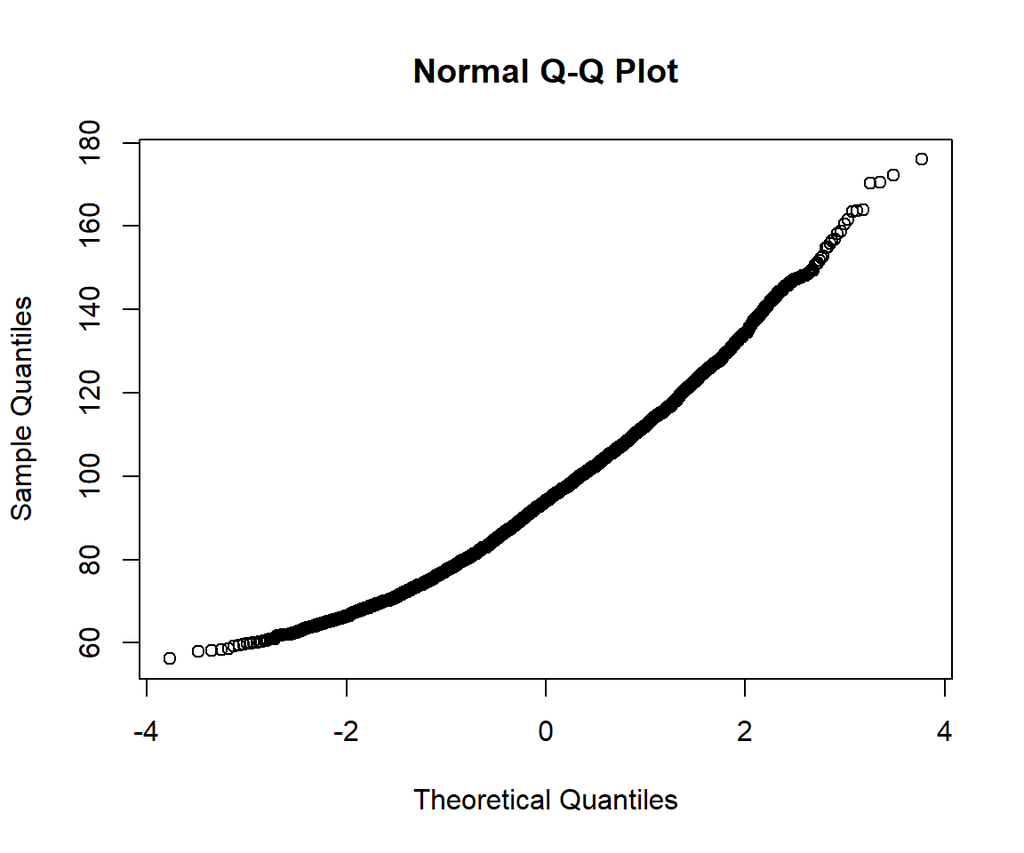

```r
qqnorm(y = merged_nhanes$BMXWAIST)
```

```r
# Let us compute the Pearson's correlation coefficient and test.
# We also plot the each pair of variables in a scatter plot.
cor.test(x = merged_nhanes$BMXWT, y = merged_nhanes$BMXHT, method = c("pearson")) # weight and height circumference
```

```
##
##  Pearson's product-moment correlation
##
## data:  merged_nhanes$BMXWT and merged_nhanes$BMXHT
## t = 40.385, df = 6449, p-value < 2.2e-16
## alternative hypothesis: true correlation is not equal to 0
## 95 percent confidence interval:
##  0.4295813 0.4685411
## sample estimates:
##       cor
## 0.4492748
```

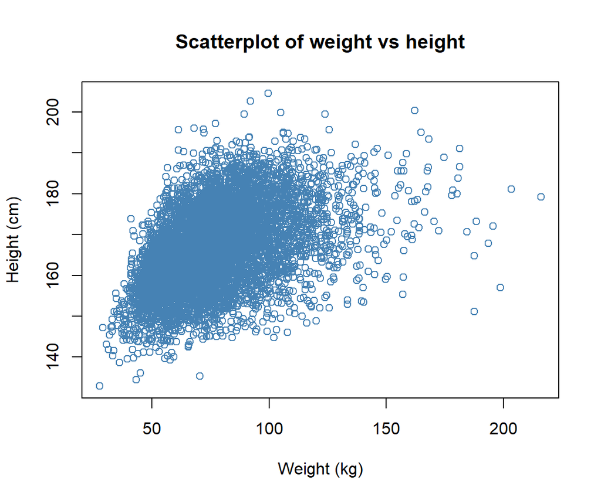

```r
plot(merged_nhanes$BMXWT, merged_nhanes$BMXHT,
     col = "steelblue",
     xlab = "Weight (kg)",
     ylab = "Height (cm)",
     main = "Scatterplot of weight vs height")
```

```r
cor.test(x = merged_nhanes$BMXWT, y = merged_nhanes$BMXWAIST, method = c("pearson")) # weight and waist circumference
```

```
##
##  Pearson's product-moment correlation
##
## data:  merged_nhanes$BMXWT and merged_nhanes$BMXWAIST
## t = 163.3, df = 6139, p-value < 2.2e-16
## alternative hypothesis: true correlation is not equal to 0
## 95 percent confidence interval:
##  0.8968025 0.9061684
## sample estimates:
##       cor
## 0.9015911
```

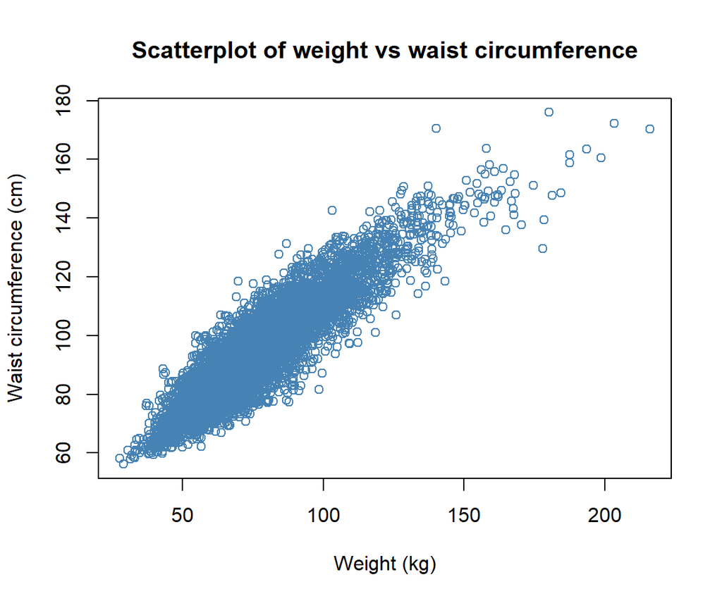

```r
plot(x = merged_nhanes$BMXWT, y = merged_nhanes$BMXWAIST,
     col = "steelblue",
     xlab = "Weight (kg)",
     ylab = "Waist circumference (cm)",
     main = "Scatterplot of weight vs waist circumference")
```

```r
cor.test(x = merged_nhanes$BMXHT, y = merged_nhanes$BMXWAIST, method = c("pearson")) # height and waist circumference
```

```
##
##  Pearson's product-moment correlation
##
## data:  merged_nhanes$BMXHT and merged_nhanes$BMXWAIST
## t = 15.907, df = 6142, p-value < 2.2e-16
## alternative hypothesis: true correlation is not equal to 0
## 95 percent confidence interval:
##  0.1747739 0.2228077
## sample estimates:
##       cor
## 0.1989103
```

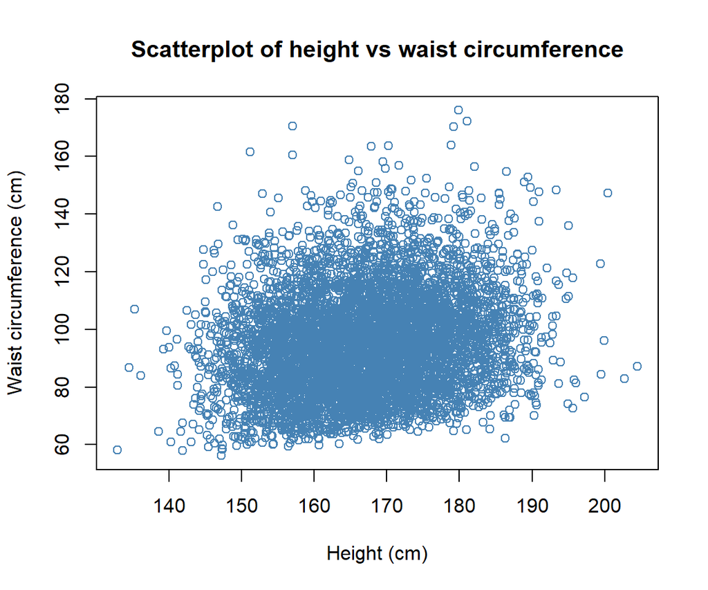

```r
plot(x = merged_nhanes$BMXHT, y = merged_nhanes$BMXWAIST,
     col = "steelblue",
     xlab = "Height (cm)",
     ylab = "Waist circumference (cm)",
     main = "Scatterplot of height vs waist circumference")
```

```r
cor.test(x = merged_nhanes$BMXWT, y = merged_nhanes$BMXBMI, method = c("pearson")) # weight and BMI
```

```
##
##  Pearson's product-moment correlation
##
## data:  merged_nhanes$BMXWT and merged_nhanes$BMXBMI
## t = 161.88, df = 6449, p-value < 2.2e-16
## alternative hypothesis: true correlation is not equal to 0
## 95 percent confidence interval:
##  0.8908943 0.9005384
## sample estimates:
##       cor
## 0.8958218
```

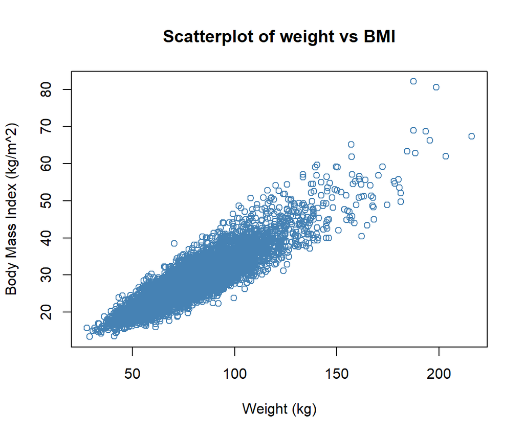

```r
plot(x = merged_nhanes$BMXWT, y = merged_nhanes$BMXBMI,
     col = "steelblue",
     xlab = "Weight (kg)",
     ylab = "Body Mass Index (kg/m^2)",
     main = "Scatterplot of weight vs BMI")
```

```r
cor.test(x = merged_nhanes$BMXHT, y = merged_nhanes$BMXBMI, method = c("pearson")) # height and BMI
```

```
##
##  Pearson's product-moment correlation
##
## data:  merged_nhanes$BMXHT and merged_nhanes$BMXBMI
## t = 1.7037, df = 6449, p-value = 0.08848
## alternative hypothesis: true correlation is not equal to 0
## 95 percent confidence interval:
##  -0.003194072  0.045590671
## sample estimates:
##        cor
## 0.02121093
```

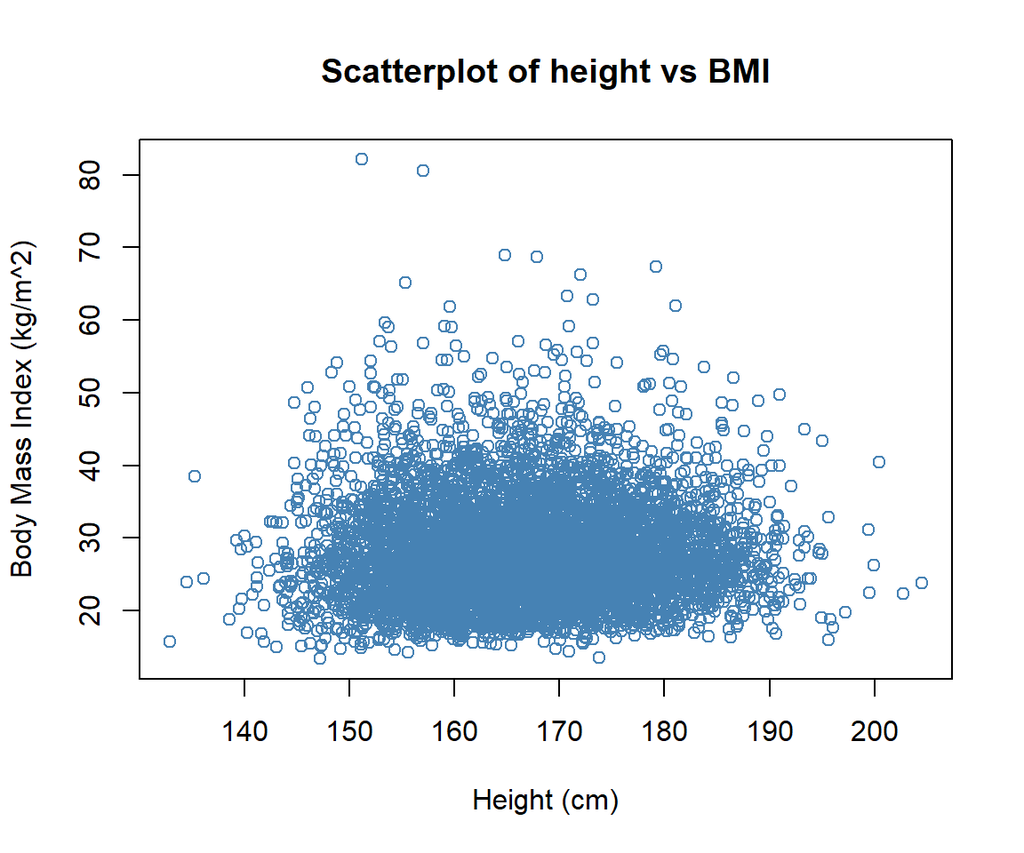

```r
plot(x = merged_nhanes$BMXHT, y = merged_nhanes$BMXBMI,
     col = "steelblue",
     xlab = "Height (cm)",
     ylab = "Body Mass Index (kg/m^2)",
     main = "Scatterplot of height vs BMI")
```

- Weight and height ($r = 0.45$) show a moderate positive association, which makes sense, since taller individuals tend to weigh more.
- Weight and waist circumference ($r = 0.90$) show a very strong positive correlation, as expected, since heavier participants generally have larger waist measurements.
- Height and waist circumference ($r = 0.20$) only have a weak positive correlation: taller participants tend to have slightly larger waists, though the effect is small. Weight has much more effect on waist circumference.
- Weight and BMI ($r = 0.90$): very strong correlation, just like we expect, as BMI is directly derived from weight.
- Height and BMI ($r = 0.02, p = 0.09$): essentially no linear relationship, because BMI already accounts for height in its formula, which explains the near-zero correlation.

Note that while height and waist circumference appear roughly normally distributed, weight and BMI are slightly right-skewed, which may slightly affect the strength of Pearson’s correlation but not the overall interpretation of direction or relative magnitude.

## 6.2 Correlation test by Spearman

The Spearman correlation coefficient $\rho$ between two variables is equal to the Pearson correlation coefficient $r$ between the **rank values** of those two variables; while Pearson’s correlation assesses linear relationships, Spearman’s correlation assesses **monotonic** (i.e. strictly increasing, but not necessarily linearly) relationships.

It also lies between $-1$ and $1$, and is interpreted similarly to the Pearson coefficient.

As it is a nonparametric test, ordinal data is also permitted.

💡 Ranking a vector of data means replacing its numerical or ordinal values by their rank, when the data are sorted. For example, the ranks of the numerical vector `c(3.4, 5.1, 2.6, 7.3)` are `c(2, 3, 1, 4)`.

1. Null hypothesis

- The correlation coefficient $\rho$ is equal to $0$ (i.e. no monotonic correlation)

2. Type of data

- Two vectors of continuous or ordinal variables (e.g. weight in [kg] and height in [m])

3. Requirements

- Values in both data vectors must be *paired*, meaning that each element in one vector corresponds to a specific element in the other.

4. R function

`cor.test(x, ...)`: Test for association between paired samples, using one of Pearson’s, Kendall’s or Spearman’s correlation coefficient.

5. Important arguments

```
cor.test(x, y,
         alternative = c("two.sided", "less", "greater"),
         method = c("pearson", "kendall", "spearman"),
         exact = NULL, conf.level = 0.95, continuity = FALSE, ...)
```

- `x, y`: numeric vectors of data values. `x` and `y` must have the same length.
- `alternative`: indicates the alternative hypothesis and must be one of “two.sided”, “greater” or “less”. You can specify just the initial letter. “greater” corresponds to positive association, “less” to negative association.
- `method`: a character string indicating which correlation coefficient is to be used for the test. One of “pearson”, “kendall”, or “spearman”, can be abbreviated.

6. Example

Let us measure the Spearman’s correlation of different pairs of variables:

- `BMXWT`: Weight (kg)
- `BMXHT`: Standing height (cm)
- `BMXBMI`: Body Mass Index (kg/m²)
- `BMXWAIST`: Waist circumference (cm)

```r
# Let us compute the Spearman's correlation coefficient and test.
# We also plot the each pair of variables in a scatter plot.
cor.test(x = merged_nhanes$BMXWT, y = merged_nhanes$BMXHT, method = c("spearman"), exact = FALSE) # weight and height circumference
```

```
##
##  Spearman's rank correlation rho
##
## data:  merged_nhanes$BMXWT and merged_nhanes$BMXHT
## S = 2.3605e+10, p-value < 2.2e-16
## alternative hypothesis: true rho is not equal to 0
## sample estimates:
##       rho
## 0.4724464
```

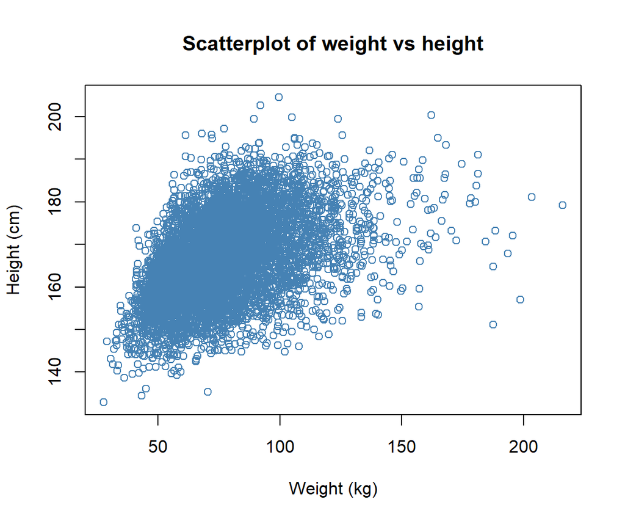

```r
plot(merged_nhanes$BMXWT, merged_nhanes$BMXHT,
     col = "steelblue",
     xlab = "Weight (kg)",
     ylab = "Height (cm)",
     main = "Scatterplot of weight vs height")
```

```r
cor.test(x = merged_nhanes$BMXWT, y = merged_nhanes$BMXWAIST, method = c("spearman"), exact = FALSE) # weight and waist circumference
```

```
##
##  Spearman's rank correlation rho
##
## data:  merged_nhanes$BMXWT and merged_nhanes$BMXWAIST
## S = 4343726277, p-value < 2.2e-16
## alternative hypothesis: true rho is not equal to 0
## sample estimates:
##       rho
## 0.8874627
```

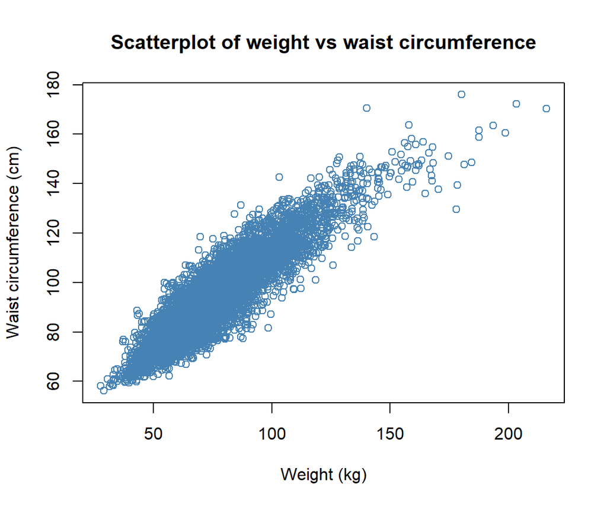

```r
plot(x = merged_nhanes$BMXWT, y = merged_nhanes$BMXWAIST,
     col = "steelblue",
     xlab = "Weight (kg)",
     ylab = "Waist circumference (cm)",
     main = "Scatterplot of weight vs waist circumference")
```

```r
cor.test(x = merged_nhanes$BMXHT, y = merged_nhanes$BMXWAIST, method = c("spearman"), exact = FALSE) # height and waist circumference
```

```
##
##  Spearman's rank correlation rho
##
## data:  merged_nhanes$BMXHT and merged_nhanes$BMXWAIST
## S = 3.1054e+10, p-value < 2.2e-16
## alternative hypothesis: true rho is not equal to 0
## sample estimates:
##      rho
## 0.196642
```

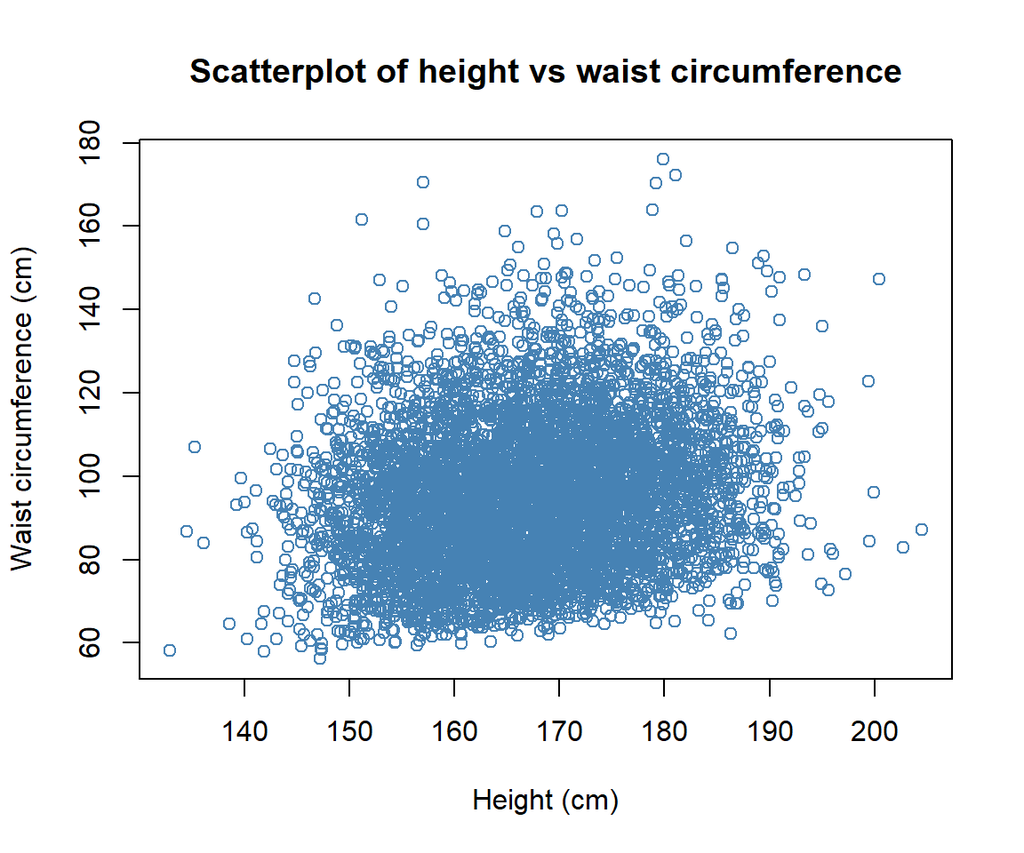

```r
plot(x = merged_nhanes$BMXHT, y = merged_nhanes$BMXWAIST,
     col = "steelblue",
     xlab = "Height (cm)",
     ylab = "Waist circumference (cm)",
     main = "Scatterplot of height vs waist circumference")
```

```r
cor.test(x = merged_nhanes$BMXWT, y = merged_nhanes$BMXBMI, method = c("spearman"), exact = FALSE) # weight and BMI
```

```
##
##  Spearman's rank correlation rho
##
## data:  merged_nhanes$BMXWT and merged_nhanes$BMXBMI
## S = 5209111770, p-value < 2.2e-16
## alternative hypothesis: true rho is not equal to 0
## sample estimates:
##       rho
## 0.8835783
```

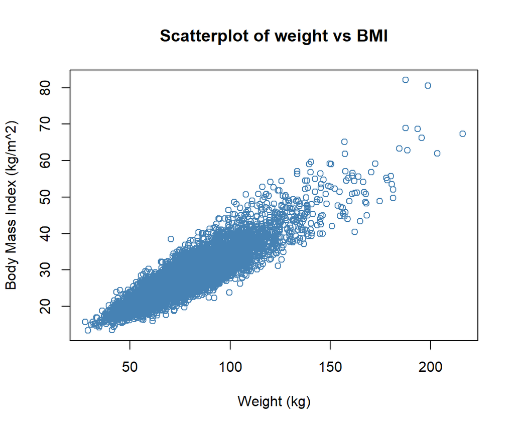

```r
plot(x = merged_nhanes$BMXWT, y = merged_nhanes$BMXBMI,
     col = "steelblue",
     xlab = "Weight (kg)",
     ylab = "Body Mass Index (kg/m^2)",
     main = "Scatterplot of weight vs BMI")
```

```r
cor.test(x = merged_nhanes$BMXHT, y = merged_nhanes$BMXBMI, method = c("spearman"), exact = FALSE) # height and BMI
```

```
##
##  Spearman's rank correlation rho
##
## data:  merged_nhanes$BMXHT and merged_nhanes$BMXBMI
## S = 4.2875e+10, p-value = 0.0007942
## alternative hypothesis: true rho is not equal to 0
## sample estimates:
##        rho
## 0.04175895
```

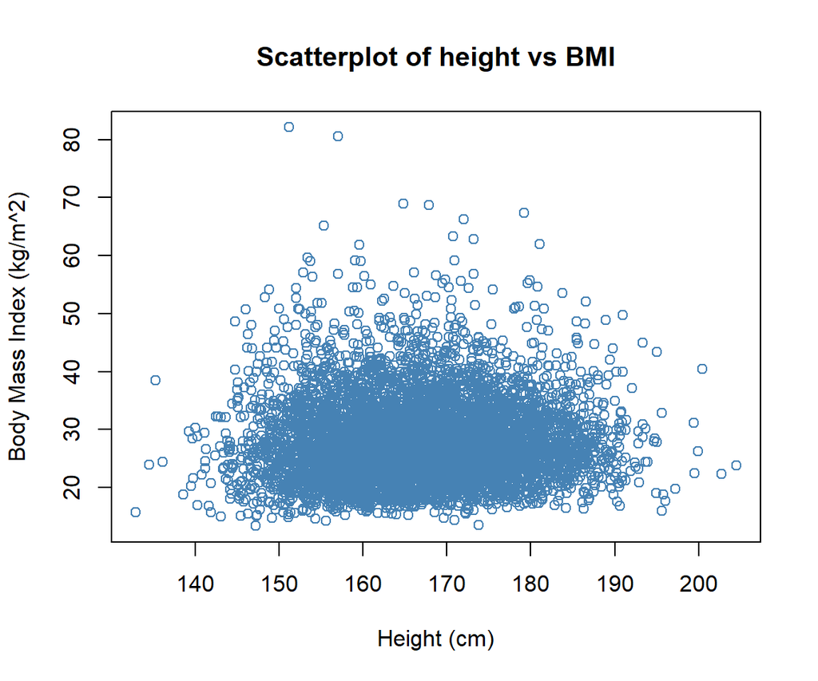

```r
plot(x = merged_nhanes$BMXHT, y = merged_nhanes$BMXBMI,
     col = "steelblue",
     xlab = "Height (cm)",
     ylab = "Body Mass Index (kg/m^2)",
     main = "Scatterplot of height vs BMI")
```

- Weight and height ($\rho = 0.47$) have a slightly stronger correlation using Spearman’s method than Pearson’s ($r = 0.45$), suggesting a monotonic but not perfectly linear increase: heavier participants tend to be taller, though not in a strictly linear way.
- Weight and waist circumference ($\rho = 0.89$) have a Spearman’s coefficient nearly identical to Pearson’s ($r = 0.90$), confirming a very strong monotonic and rather linear association.
- Height and waist circumference ($\rho = 0.20$) have identical Spearman’s and Pearson’s ($r = 0.20$) coefficients, suggesting a weak but positive and linear relationship.
- Weight and BMI ($\rho = 0.88$): their Spearman’s coefficient is almost the same as their Pearson’s coefficient ($r = 0.90$), again reflecting the strong link between weight and BMI’s definition.
- Height and BMI ($\rho = 0.04, p < 0.001$): although statistically significant due to large sample size, the correlation remains basically nonexistent. There is practically no monotonic association.

# 7 Regression

Regression analysis is a statistical method for estimating the **relationship** between one or more explanatory variables and one or more response variables.

Regression analysis can be used for conceptually distinct purposes: * to show association between explanatory and response variables, * to predict new values of the response variable, * or, and this has to be especially well justified, to infer causal relationships between explanatory and response variables.

You are probably already familiar with linear regression. However, linear regression can be viewed within a broader framework called Generalized Linear Models (GLMs). We will first lay the foundation for understanding GLMs before focusing on two GLMs that are widely used in medicine:

- Linear regression: for continuous outcomes (e.g. total lung capacity in liters).
- Logistic regression: for binary outcomes (e.g. presence or absence of a disease).

After discussing GLMs, we will move on to another type of regression model designed to handle time-to-event (i.e. censored) data: the Cox regression model (e.g. overall survival).

💡 In this lecture, we will refer to the variable that we aim to explain with our regression model as the **response variable** or **output variable**. The variables that we use to make this prediction will be called **input variables** or **explanatory variables**. Different fields (medicine, statistics, economics, etc.) may use other names for these variables, which we summarize in the list below.

| Field | Output Variable | Input Variable |
| --- | --- | --- |
| Statistics / Data Science | Response variable | Predictor variable / Covariate |
| Medicine / Epidemiology | Outcome | Risk factor / Exposure / Covariate |
| Economics / Social Sciences | Dependent variable | Independent variable / Regressor |
| Machine Learning | Target | Feature / Input |
| General / Other fields | Output | Input / Explanatory |

⚠️ I strongly advise *against* using the terms *dependent and independent* variables, because these terms can misleadingly imply that some variables are fully independent of others or suggest a causal relationship.

## 7.1 Generalized Linear Models (GLMs)

Generalized linear models (GLMs) are an extension of linear models that

1. allow for response variables with *arbitrary distributions* (rather than simply normal distributions)
2. and an arbitrary function of the response variable (the *link function*) that varies linearly with the predictors (rather than the response itself being assumed to vary linearly).

In short: They offer more flexibility than traditional linear regression.

[output not shown]

💡 Notes:

- $y_i$ is the response variable.
- $x_{ij}$ are the explanatory (input) variables.
- $g(\cdot)$ is the link function, e.g.
  - Identity link → linear regression
  - Logit link → logistic regression
  - Log link → Poisson regression

GLMs consist of three elements:

1. Linear relationship: GLMs assume a linear relationship between the predictors and the transformed response variable.
2. Link function $g(\cdot)$: Links the linear predictor to the mean of the distribution. Common link functions:
- Identity link for normal distribution (linear regression): $g(p)=p$
- Logit link for binomial distribution (logistic regression): $g(p)=\text{logit}(p)=\ln\left(\frac{p}{1-p}\right)$
- Log link for Poisson distribution (Poisson regression): $g(p)=\text{log}(p)$
3. Output distribution: GLMs can be applied with various distributions for modelling the output:
- Normal for continuous data (linear regression)
- Binomial for binary data (logistic regression)
- Poisson for count data (Poisson regression)

1. Null hypothesis

Regression as a whole does not have a single null hypothesis, it is primarily a method for estimating coefficients that best fit the data. However, each coefficient in the model can be tested individually under the null hypothesis that it equals zero (i.e. that the corresponding explanatory variable has no effect on the response variable).

2. Type of data

The type of regression used within the GLM framework depends on the nature of the response variable:

- Continuous → Linear regression (e.g. blood pressure, cholesterol level)
- Binary → Logistic regression (e.g. smoker vs. non-smoker)
- Count / Discrete → Poisson regression (e.g. number of hospital visits)

3. Requirements

- Observations must be *independent*.
- The response variable follows an *appropriate distribution* (e.g., binomial for binary outcomes, Poisson for count data).

⚠️ A possible point of confusion has to do with the distinction between **generalized linear models** (discussed here) and **general (multivariate) linear models** (which is simply a compact way of simultaneously writing several multiple linear regression models).

### 7.1.1 Linear regression

From the perspective of generalized linear models, it is useful to suppose that the distribution function is the normal distribution with constant variance and the link function is the identity: under these assumptions, the least-squares estimator is obtained as the maximum-likelihood parameter estimate.

2. Type of data

Continuous response variable.

3. Requirements

- Linearity: the relationship between each predictor and outcome must be *linear*.
- Normality of residuals: the *residuals* should follow a *normal* distribution.
- Constant variance (a.k.a. *homoscedasticity*): the variance of the residuals does not depend on the values of the predictor variables.
- Independence: the *observations* should be *independent* (not repeated measures).

💡 Residuals are the difference between a real-world observation and a value predicted by a model.

4. R function

`glm(formula, family, ...)`: is used to fit generalized linear models, specified by giving a symbolic description of the linear predictor and a description of the error distribution.

5. Important arguments

```
glm(formula, family = gaussian, data, weights, subset,
    na.action, start = NULL, etastart, mustart, offset,
    control = list(...), model = TRUE, method = "glm.fit",
    x = FALSE, y = TRUE, singular.ok = TRUE, contrasts = NULL, ...)
```

- `formula`: an object of class “formula” (or one that can be coerced to that class), a symbolic description of the model to be fitted.
- `family`: a description of the error distribution and link function to be used in the model.
- `data`: an optional data frame, list or environment (or object coercible by as.data.frame to a data frame) containing the variables in the model.
- `na.action`: a function which indicates what should happen when the data contain NAs. The default is set by the `na.action` setting of options. The ‘factory-fresh’ default is `na.omit`.

6. Example

```r
library(DescTools) # DescTools to compute (pseudo) coefficients of determination

# Look at how BMI and other predictors (age, gender, race, smoking habits)
# influence systolic blood pressure (first reading)
data_noNA <- na.omit(merged_nhanes[, c("BPXSY1", "BMXBMI", "RIDAGEYR", "RIAGENDR", "RIDRETH1", "SMQ020")])

# --------------------------------------------------
# 1. Linear model (BMI only)
# --------------------------------------------------
model_linear <- glm(BPXSY1 ~ BMXBMI, data = data_noNA, family = gaussian())
summary(model_linear)
```

```
##
## Call:
## glm(formula = BPXSY1 ~ BMXBMI, family = gaussian(), data = data_noNA)
##
## Coefficients:
##              Estimate Std. Error t value Pr(>|t|)
## (Intercept) 115.56402    1.15874  99.732  < 2e-16 ***
## BMXBMI        0.29552    0.03923   7.533 5.91e-14 ***
## ---
## Signif. codes:  0 '***' 0.001 '**' 0.01 '*' 0.05 '.' 0.1 ' ' 1
##
## (Dispersion parameter for gaussian family taken to be 348.3148)
##
##     Null deviance: 1691674  on 4801  degrees of freedom
## Residual deviance: 1671911  on 4800  degrees of freedom
## AIC: 41738
##
## Number of Fisher Scoring iterations: 2
```

```r
# Coefficient of determination (pseudo R² for GLM)
PseudoR2(model_linear, which = "CoxSnell")
```

```
##   CoxSnell
## 0.01168272
```

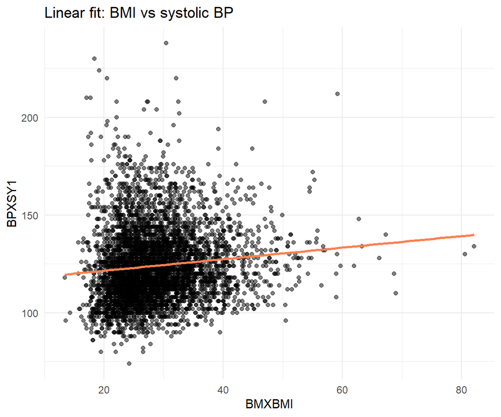

```r
# Plot linear fit
ggplot(data_noNA, aes(x = BMXBMI, y = BPXSY1)) +
  geom_point(alpha = 0.5) +
  stat_smooth(method = "glm", formula = y ~ x, se = FALSE, color = "coral") +
  labs(title = "Linear fit: BMI vs systolic BP") +
  theme_minimal()
```

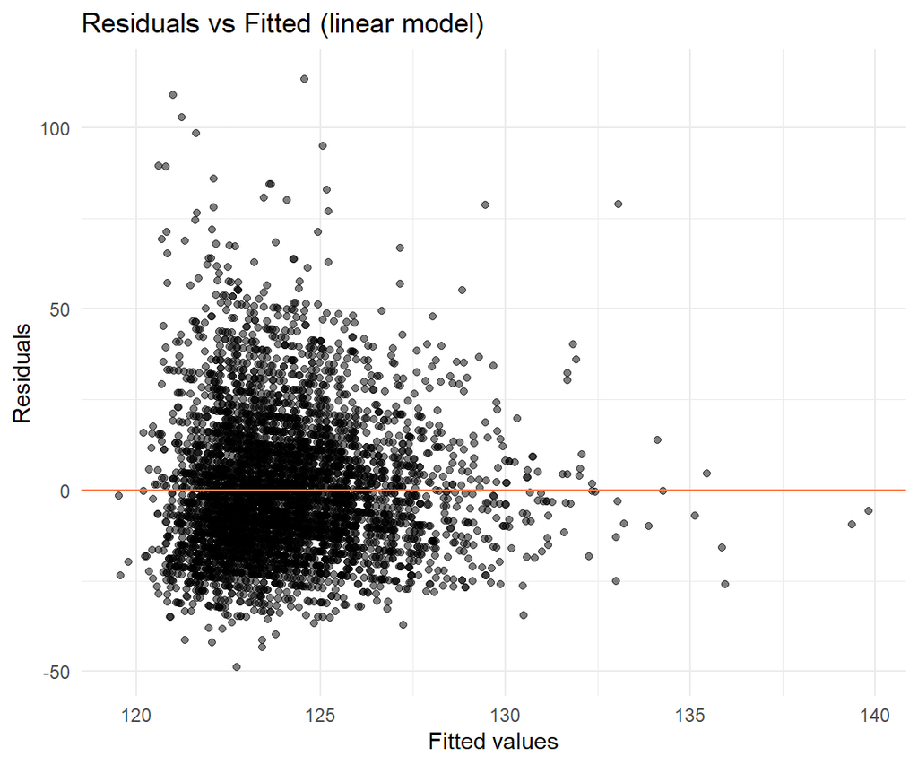

```r
# Residuals vs fitted values
resid_df <- data.frame(
  Fitted = fitted(model_linear),
  Residuals = residuals(model_linear)
)
ggplot(resid_df, aes(x = Fitted, y = Residuals)) +
  geom_point(alpha = 0.5) +
  geom_hline(yintercept = 0, color = "coral") +
  labs(
    title = "Residuals vs Fitted (linear model)",
    x = "Fitted values",
    y = "Residuals"
  ) +
  theme_minimal()
```

```r
# --------------------------------------------------
# 2. Quadratic model (BMI + BMI^2)
# --------------------------------------------------
model_quad <- glm(BPXSY1 ~ BMXBMI + I(BMXBMI^2), data = data_noNA, family = gaussian())
summary(model_quad)
```

```
##
## Call:
## glm(formula = BPXSY1 ~ BMXBMI + I(BMXBMI^2), family = gaussian(),
##     data = data_noNA)
##
## Coefficients:
##               Estimate Std. Error t value Pr(>|t|)
## (Intercept) 110.300185   3.242301  34.019  < 2e-16 ***
## BMXBMI        0.632181   0.197612   3.199  0.00139 **
## I(BMXBMI^2)  -0.005052   0.002907  -1.738  0.08223 .
## ---
## Signif. codes:  0 '***' 0.001 '**' 0.01 '*' 0.05 '.' 0.1 ' ' 1
##
## (Dispersion parameter for gaussian family taken to be 348.1682)
##
##     Null deviance: 1691674  on 4801  degrees of freedom
## Residual deviance: 1670859  on 4799  degrees of freedom
## AIC: 41737
##
## Number of Fisher Scoring iterations: 2
```

```r
# Coefficient of determination
PseudoR2(model_quad, which = "CoxSnell")
```

```
##   CoxSnell
## 0.01230457
```

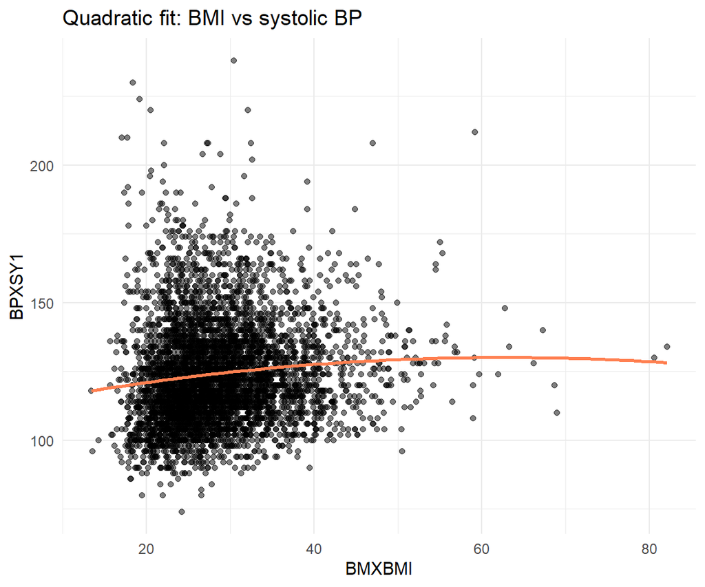

```r
# Plot quadratic fit
ggplot(data_noNA, aes(x = BMXBMI, y = BPXSY1)) +
  geom_point(alpha = 0.5) +
  stat_smooth(method = "glm", formula = y ~ x + I(x^2), se = FALSE, color = "coral") +
  labs(title = "Quadratic fit: BMI vs systolic BP") +
  theme_minimal()
```

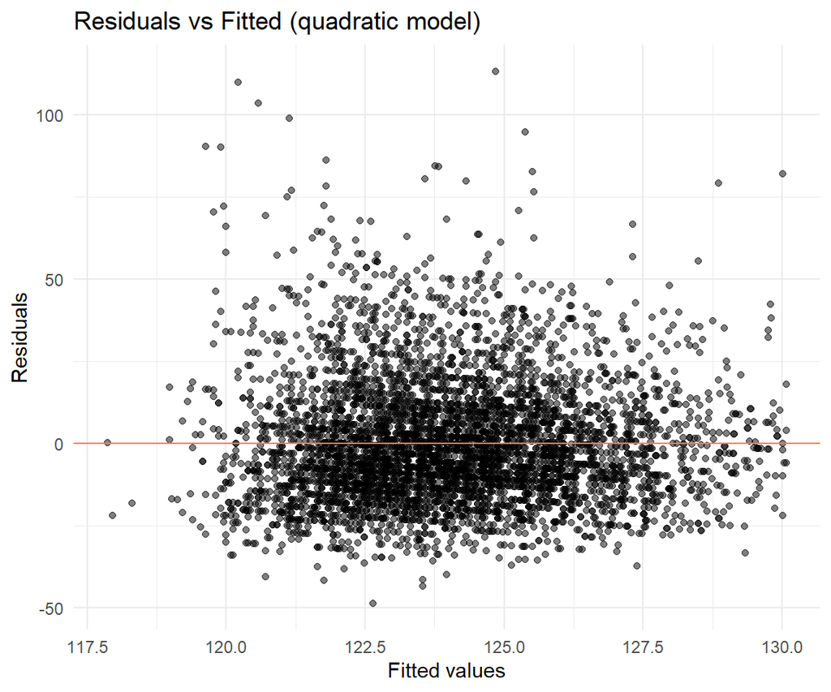

```r
# Residuals vs fitted values
resid_quad_df <- data.frame(
  Fitted = fitted(model_quad),
  Residuals = residuals(model_quad)
)
ggplot(resid_quad_df, aes(x = Fitted, y = Residuals)) +
  geom_point(alpha = 0.5) +
  geom_hline(yintercept = 0, color = "coral") +
  labs(
    title = "Residuals vs Fitted (quadratic model)",
    x = "Fitted values",
    y = "Residuals"
  ) +
  theme_minimal()
```

```r
# --------------------------------------------------
# 3. Multivariable linear model
# --------------------------------------------------
model_multi <- glm(BPXSY1 ~ BMXBMI + RIDAGEYR + RIAGENDR + RIDRETH1 + SMQ020,
                   data = data_noNA, family = gaussian())
summary(model_multi)
```

```
##
## Call:
## glm(formula = BPXSY1 ~ BMXBMI + RIDAGEYR + RIAGENDR + RIDRETH1 +
##     SMQ020, family = gaussian(), data = data_noNA)
##
## Coefficients:
##                                              Estimate Std. Error t value
## (Intercept)                                 104.17705   11.65891   8.935
## BMXBMI                                        0.21146    0.03564   5.934
## RIDAGEYR                                      0.48037    0.01356  35.434
## RIAGENDRMale                                  3.95487    0.48453   8.162
## RIDRETH1Non-Hispanic Black                    4.99831    0.89100   5.610
## RIDRETH1Non-Hispanic White                   -0.41692    0.86448  -0.482
## RIDRETH1Other Hispanic                       -0.39868    1.06531  -0.374
## RIDRETH1Other Race - Including Multi-Racial  -0.16703    0.96917  -0.172
## SMQ020No                                    -12.92621   11.56418  -1.118
## SMQ020Refused                                 4.54091   20.03072   0.227
## SMQ020Yes                                   -12.42389   11.56556  -1.074
##                                             Pr(>|t|)
## (Intercept)                                  < 2e-16 ***
## BMXBMI                                      3.17e-09 ***
## RIDAGEYR                                     < 2e-16 ***
## RIAGENDRMale                                4.16e-16 ***
## RIDRETH1Non-Hispanic Black                  2.14e-08 ***
## RIDRETH1Non-Hispanic White                     0.630
## RIDRETH1Other Hispanic                         0.708
## RIDRETH1Other Race - Including Multi-Racial    0.863
## SMQ020No                                       0.264
## SMQ020Refused                                  0.821
## SMQ020Yes                                      0.283
## ---
## Signif. codes:  0 '***' 0.001 '**' 0.01 '*' 0.05 '.' 0.1 ' ' 1
##
## (Dispersion parameter for gaussian family taken to be 267.1182)
##
##     Null deviance: 1691674  on 4801  degrees of freedom
## Residual deviance: 1279763  on 4791  degrees of freedom
## AIC: 40473
##
## Number of Fisher Scoring iterations: 2
```

```r
# Pseudo R²
PseudoR2(model_multi, which = "CoxSnell")
```

```
##  CoxSnell
## 0.2434933
```

💡 The coefficient of determination, denoted `R^2` and pronounced “R squared”, is the proportion of the variation in the outcome variable that is predictable from the predictor(s). It provides a measure of how well observed outcomes are replicated by the model, based on the proportion of total variation of outcomes explained by the model. A value of 0 means the model explains none of the variance and a value of 1 means it explains all of it. Pseudo R-squared is a measure of goodness-of-fit for models where R-squared cannot be calculated, such as logistic regression. Cox and Snell’s R^2 is based on the log likelihood for the model compared to the log likelihood for a baseline model.

💡 When conducting a residual analysis, a “residuals versus fits plot” is the most frequently created plot. It is a scatter plot of residuals on the y axis and fitted values (estimated responses) on the x axis. The plot is used to detect non-linearity, unequal error variances, and outliers. What we wish:

- The residuals “bounce randomly” around the 0 line. This suggests that the assumption that the relationship is linear is reasonable.
- The residuals roughly form a “horizontal band” around the 0 line. This suggests that the variances of the error terms are equal.
- No one residual “stands out” from the basic random pattern of residuals. This suggests that there are no outliers.

### 7.1.2 Logistic regression

2. Type of data

Binary response variable.

3. Requirements

- Linearity: the relationship between the *log-odds of the outcome* and each predictor must be *linear*.
- Independence: the *observations* should be *independent* (not repeated measures).
- Large sample size: a general guideline is that you need a *minimum of about 10 events* per explanatory variable.

4. R function

See “Linear regression”.

5. Important arguments

See “Linear regression”.

6. Example

```r
library(DescTools) # DescTools to compute (pseudo) coefficients of determination

# Outcome: marital status (DMDMARTL > married = 1 if married, 0 otherwise)
# Input: age, gender, education level, household income
data_logit <- na.omit(merged_nhanes[, c("DMDMARTL", "RIDAGEYR", "RIAGENDR", "DMDEDUC2", "INDHHIN2")])

# Convert marital status to binary: 1 = Married, 0 = Not married
data_logit$married <- ifelse(data_logit$DMDMARTL == "Married", 1, 0)

# --------------------------------------------------
# 1. Logistic regression: single predictor
# --------------------------------------------------
model_logit <- glm(married ~ RIDAGEYR, data = data_logit, family = binomial())
summary(model_logit)
```

```
##
## Call:
## glm(formula = married ~ RIDAGEYR, family = binomial(), data = data_logit)
##
## Coefficients:
##              Estimate Std. Error z value Pr(>|z|)
## (Intercept) -0.887292   0.082312  -10.78   <2e-16 ***
## RIDAGEYR     0.017010   0.001584   10.73   <2e-16 ***
## ---
## Signif. codes:  0 '***' 0.001 '**' 0.01 '*' 0.05 '.' 0.1 ' ' 1
##
## (Dispersion parameter for binomial family taken to be 1)
##
##     Null deviance: 7308.5  on 5274  degrees of freedom
## Residual deviance: 7190.8  on 5273  degrees of freedom
## AIC: 7194.8
##
## Number of Fisher Scoring iterations: 4
```

```r
# Pseudo R²
PseudoR2(model_logit, which = "CoxSnell")
```

```
##   CoxSnell
## 0.02206507
```

```r
# Predicted probabilities
data_logit$pred_prob <- fitted(model_logit)

# --------------------------------------------------
# 2. Multivariable logistic regression
# --------------------------------------------------
model_logit_multi <- glm(married ~ RIDAGEYR + RIAGENDR + DMDEDUC2 + INDHHIN2,
                         data = data_logit, family = binomial())
summary(model_logit_multi)
```

```
##
## Call:
## glm(formula = married ~ RIDAGEYR + RIAGENDR + DMDEDUC2 + INDHHIN2,
##     family = binomial(), data = data_logit)
##
## Coefficients:
##                                                  Estimate Std. Error z value
## (Intercept)                                     -2.748827   0.274548 -10.012
## RIDAGEYR                                         0.021009   0.001756  11.961
## RIAGENDRMale                                     0.291431   0.059417   4.905
## DMDEDUC2College graduate or above                0.033443   0.106686   0.313
## DMDEDUC2Don't Know                              -0.815127   1.239294  -0.658
## DMDEDUC2High school graduate/GED or equivalent  -0.111249   0.102820  -1.082
## DMDEDUC2Less than 9th grade                      0.110769   0.123854   0.894
## DMDEDUC2Refused                                -11.737591 196.967748  -0.060
## DMDEDUC2Some college or AA degree               -0.298238   0.098347  -3.033
## INDHHIN2$ 5,000 to $ 9,999                      -0.218551   0.308268  -0.709
## INDHHIN2$10,000 to $14,999                       0.636371   0.274571   2.318
## INDHHIN2$100,000 and Over                        2.504320   0.265692   9.426
## INDHHIN2$15,000 to $19,999                       1.091333   0.273519   3.990
## INDHHIN2$20,000 and Over                         1.407724   0.288072   4.887
## INDHHIN2$20,000 to $24,999                       1.432969   0.271556   5.277
## INDHHIN2$25,000 to $34,999                       1.549836   0.266063   5.825
## INDHHIN2$35,000 to $44,999                       1.656426   0.267819   6.185
## INDHHIN2$45,000 to $54,999                       1.983391   0.276159   7.182
## INDHHIN2$55,000 to $64,999                       1.967894   0.285847   6.884
## INDHHIN2$65,000 to $74,999                       2.242188   0.285867   7.843
## INDHHIN2$75,000 to $99,999                       2.245929   0.272835   8.232
## INDHHIN2Don't know                               0.624514   0.355345   1.757
## INDHHIN2Refused                                  1.654013   0.308811   5.356
## INDHHIN2Under $20,000                            1.251662   0.375427   3.334
##                                                Pr(>|z|)
## (Intercept)                                     < 2e-16 ***
## RIDAGEYR                                        < 2e-16 ***
## RIAGENDRMale                                   9.35e-07 ***
## DMDEDUC2College graduate or above              0.753920
## DMDEDUC2Don't Know                             0.510709
## DMDEDUC2High school graduate/GED or equivalent 0.279264
## DMDEDUC2Less than 9th grade                    0.371135
## DMDEDUC2Refused                                0.952481
```

[output cut: 11 more lines]

```
## INDHHIN2$65,000 to $74,999                     4.38e-15 ***
## INDHHIN2$75,000 to $99,999                      < 2e-16 ***
## INDHHIN2Don't know                             0.078835 .
## INDHHIN2Refused                                8.51e-08 ***
## INDHHIN2Under $20,000                          0.000856 ***
## ---
## Signif. codes:  0 '***' 0.001 '**' 0.01 '*' 0.05 '.' 0.1 ' ' 1
##
## (Dispersion parameter for binomial family taken to be 1)
##
##     Null deviance: 7308.5  on 5274  degrees of freedom
## Residual deviance: 6555.9  on 5251  degrees of freedom
## AIC: 6603.9
##
## Number of Fisher Scoring iterations: 10
```

```r
# Pseudo R²
PseudoR2(model_logit_multi, which = "CoxSnell")
```

```
## CoxSnell
## 0.132959
```

## 7.2 Cox (proportional hazards) regression

Cox regression is used for survival analysis, particularly when studying the time to an event (e.g., time to death, time to recurrence).

2. Type of data

Time-to-event response variable.

3. Requirements

- *Proportional hazards* assumption, meaning the effect of the predictor on the hazard rate is *constant over time*.

### 7.2.1 Hazard function

The hazard function describes the instantaneous risk of experiencing the event of interest at a particular time, assuming the individual has survived up to that point. In survival analysis, it’s like asking: “At this exact moment, how likely is it that the event happens next?”

In the Cox proportional hazards model, the hazard function is expressed as the product of a baseline hazard and a factor that depends on the covariates.

$$h(t) = h_0(t) * \exp(\sum_{i=1}^{p} \beta_i x_i)$$

A Cox model assumes **proportional hazards**. This means that the effect of the covariates on the hazard is multiplicative and **constant over time**. Each covariate scales the baseline hazard by a fixed proportion, regardless of when the event occurs. For example, if a covariate doubles the hazard, it does so at every point in time.

4. R function

`coxph(formula, ...)`: Fits a Cox proportional hazards regression model.

5. Important arguments

```
coxph(formula, data=, weights, subset,
      na.action, init, control,
      ties=c("efron","breslow","exact"),
      singular.ok=TRUE, robust,
      model=FALSE, x=FALSE, y=TRUE, tt, method=ties,
      id, cluster, istate, statedata, nocenter=c(-1, 0, 1), ...)
```

- `formula`: a formula object, with the response on the left of a ~ operator, and the terms on the right. The response must be a survival object as returned by the `Surv` function.
- `data`: a data.frame in which to interpret the variables named in the formula.
- `na.action`: a missing-data filter function.

6. Example

```r
library(survival) # for survival analysis (Surv, coxph)
library(survminer) # for survival analysis (ggsurvplot)

# Select relevant columns and remove missing
cox_data <- merged_nhanes_with_mort %>%
  select(MORTSTAT, PERMTH_EXM, SMQ020) %>%
  filter(!is.na(SMQ020) & SMQ020 != "Refused" & SMQ020 != "Dont' know") %>%
  mutate(
    smoker = case_when(
      SMQ020 == "Yes" ~ "Yes",
      SMQ020 == "No" ~ "No"
    ),
    smoker = factor(smoker, levels = c("Yes", "No"))
  )

# --------------------------------------------------
# 1. Fit simple Cox model: effect of smoking
# --------------------------------------------------
cox_model <-  coxph(Surv(PERMTH_EXM, MORTSTAT) ~ smoker, data = cox_data)
summary(cox_model)
```

```
## Call:
## coxph(formula = Surv(PERMTH_EXM, MORTSTAT) ~ smoker, data = cox_data)
##
##   n= 5261, number of events= 536
##    (56 observations deleted due to missingness)
##
##              coef exp(coef) se(coef)      z Pr(>|z|)
## smokerNo -0.64678   0.52373  0.08759 -7.384 1.53e-13 ***
## ---
## Signif. codes:  0 '***' 0.001 '**' 0.01 '*' 0.05 '.' 0.1 ' ' 1
##
##          exp(coef) exp(-coef) lower .95 upper .95
## smokerNo    0.5237      1.909    0.4411    0.6218
##
## Concordance= 0.581  (se = 0.012 )
## Likelihood ratio test= 55.53  on 1 df,   p=9e-14
## Wald test            = 54.53  on 1 df,   p=2e-13
## Score (logrank) test = 56.46  on 1 df,   p=6e-14
```

```r
# Hazard ratio for smokers vs non-smokers
exp(coef(cox_model))
```

```
## smokerNo
## 0.523727
```

```r
exp(confint(cox_model))
```

```
##              2.5 %    97.5 %
## smokerNo 0.4411137 0.6218124
```

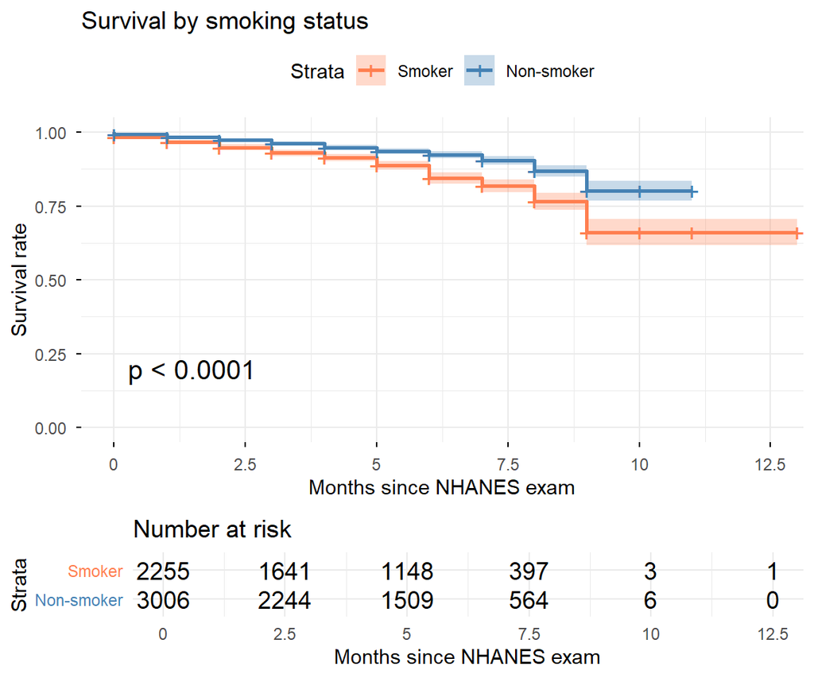

```r
# --------------------------------------------------
# 2. Kaplan-Meier curves by smoking status
# --------------------------------------------------
km_fit <- survfit(Surv(PERMTH_EXM, MORTSTAT) ~ smoker, data = cox_data)

ggsurvplot(
  fit = km_fit,
  data = cox_data,
  risk.table = TRUE,
  pval = TRUE,
  conf.int = TRUE,
  legend.labs = c("Smoker", "Non-smoker"),
  palette = c("coral", "steelblue"),  # colors for the lines
  title = "Survival by smoking status",
  xlab = "Months since NHANES exam",
  ylab = "Survival rate",
  ggtheme = theme_minimal()
)
```

### 7.2.2 Competing risks

Competing risks occur when an individual can experience one of several mutually exclusive events, and the occurrence of one event prevents the others from happening. For example, in a study of time to heart attack, death from cancer is a competing risk: once a person dies of cancer, they can no longer have a heart attack. This has to be taken into account when planning a survival analysis.

# 8 Exercises & Solutions

## 8.1 Exercises

### 8.1.1 Exercise 1

✏️ Exercise 1: Compare the systolic blood pressure (1st reading, in mmHg, `BPXSY1`) between males and females (`RIAGENDR`). To choose the right test, determine if the data is roughly normal or skewed.

### 8.1.2 Exercise 2

✏️ Exercise 2: Compare the age of the household reference person (`DMDHRAGE`) between participants who smoke at least 100 cigarettes in life (`SMQ020 == "Yes"`) and non-smokers (`SMQ020 == "No"`). To choose the right test, determine if the data is roughly normal or skewed.

### 8.1.3 Exercise 3

✏️ Exercise 3: Test whether smoking at least 100 cigarettes in life (`SMQ020 == "Yes"` and `SMQ020 == "No"`) differs by marital status of the household reference person (`DMDHRMAR == "Married"` vs every other marital status).

### 8.1.4 Exercise 4

✏️ Exercise 4: Test the association between marital status of the participant (`DMDMARTL == Married` and `DMDMARTL == Living with partner` vs all other cases) and pregnancy at exam (`RIDEXPRG == Yes, positive lab pregnancy test or self-reported pregnant at exam` vs `RIDEXPRG == The participant was not pregnant at exam`, and leave out the uncertain cases).

### 8.1.5 Exercise 5

✏️ Exercise 5: Compare mean BMI (`BMXBMI`) across age groups (please choose the groups `"(10,20]", "(20,30]", "(30,40]", "(40,50]", "(50,60]", "(60,70]"`).

💡 Hint: remember how we used the function `cut()` to create age groups in Chapter 3.

### 8.1.6 Exercise 6

✏️ Exercise 6: Check visually if BMI (`BMXBMI`) is normally distributed.

### 8.1.7 Exercise 7

✏️ Exercise 7: Compare BMI (`BMXBMI`) across different smoking frequency categories (`SMQ040`).

### 8.1.8 Exercise 8

✏️ Exercise 8: Compute the Pearson correlation between weight (`BMXWT`) and BMI (`BMXBMI`). Compute the Spearman correlation between height (`BMXHT`) and waist circumference (`BMXWAIST`).

### 8.1.9 Exercise 9

✏️ Exercise 9: Using the NHANES mortality data (`MORTSTAT`, `PERMTH_INT`), plot the Kaplan–Meier survival curve by gender. Then perform a Log-Rank test to compare survival curves.

### 8.1.10 Exercise 10

✏️ Exercise 10: Fit a linear regression model predicting systolic blood pressure (`BPXSY1`) using age (`RIDAGEYR`) and BMI (`BMXBMI`) as predictors. Interpret the coefficients.

### 8.1.11 Exercise 11

✏️ Exercise 11: Predict the probability of being a smoker (`SMQ020 == "Yes"`) using age and BMI as predictors. Interpret the coefficients.

## 8.2 Solutions

### 8.2.1 Exercise 1

☑️ Exercise 1

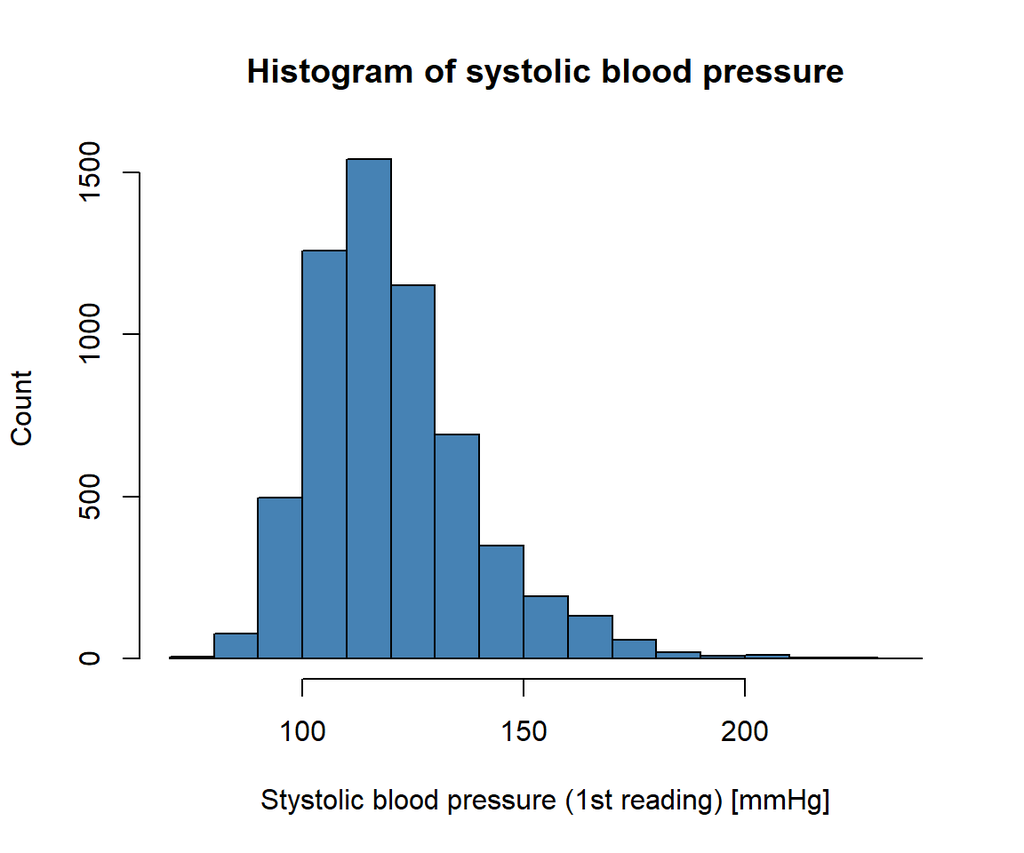

```r
# Let us have a look at the systolic blood pressure in our data set
hist(merged_nhanes$BPXSY1,
     col = "steelblue",
     xlab = "Stystolic blood pressure (1st reading) [mmHg]",
     ylab = "Count",
     main = "Histogram of systolic blood pressure")
```

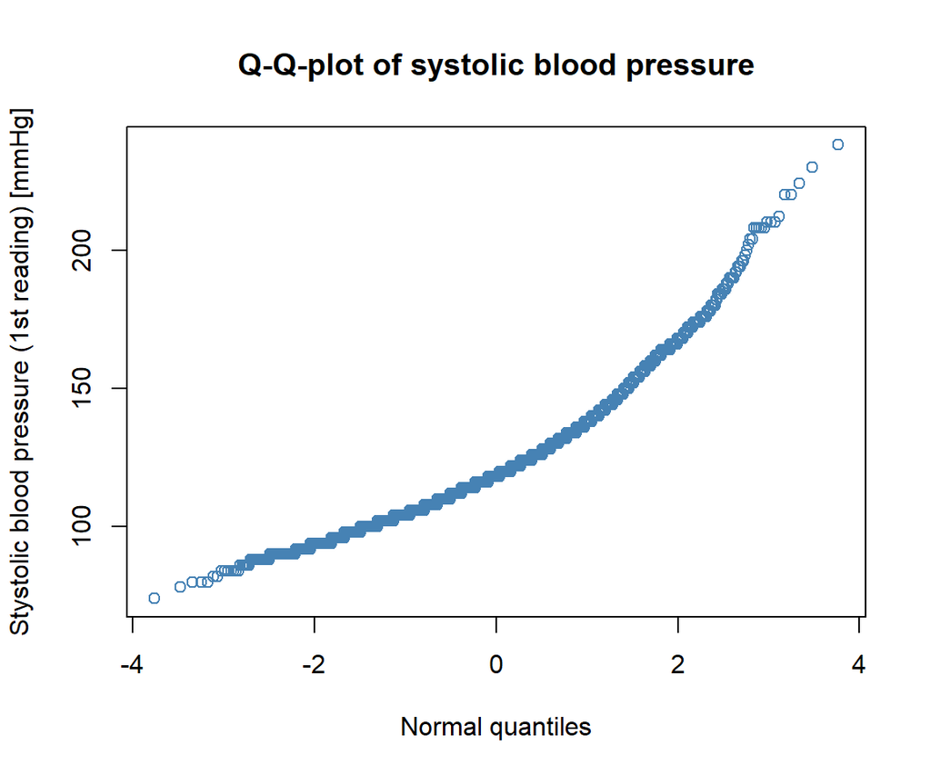

```r
qqnorm(merged_nhanes$BPXSY1,
     col = "steelblue",
     xlab = "Normal quantiles",
     ylab = "Stystolic blood pressure (1st reading) [mmHg]",
     main = "Q-Q-plot of systolic blood pressure")
```

```r
# Since the distribution is only slightly right-skewed, and we have a lot of data, we run a t-test to compare both groups (males and females)
females <- merged_nhanes[merged_nhanes$RIAGENDR == "Female",]$BPXSY1
males <- merged_nhanes[merged_nhanes$RIAGENDR == "Male",]$BPXSY1
t.test(x = females, y = males,
       alternative = c("two.sided"))
```

```
##
##  Welch Two Sample t-test
##
## data:  females and males
## t = -7.9762, df = 5859.3, p-value = 1.801e-15
## alternative hypothesis: true difference in means is not equal to 0
## 95 percent confidence interval:
##  -4.724457 -2.860302
## sample estimates:
## mean of x mean of y
##  119.4635  123.2559
```

```r
# The p-value is highly significant (p-value = 1.801e-15)

# If the data had been to skewed, we could have used a Wilcoxon rank-sum test (also called Mann–Whitney U test)
```